# 市场观察

2016/06/17

## 一、指数估值

### (一)指数动态市盈率

核心指数成分股的动态市盈率中位数走势如下图所示：

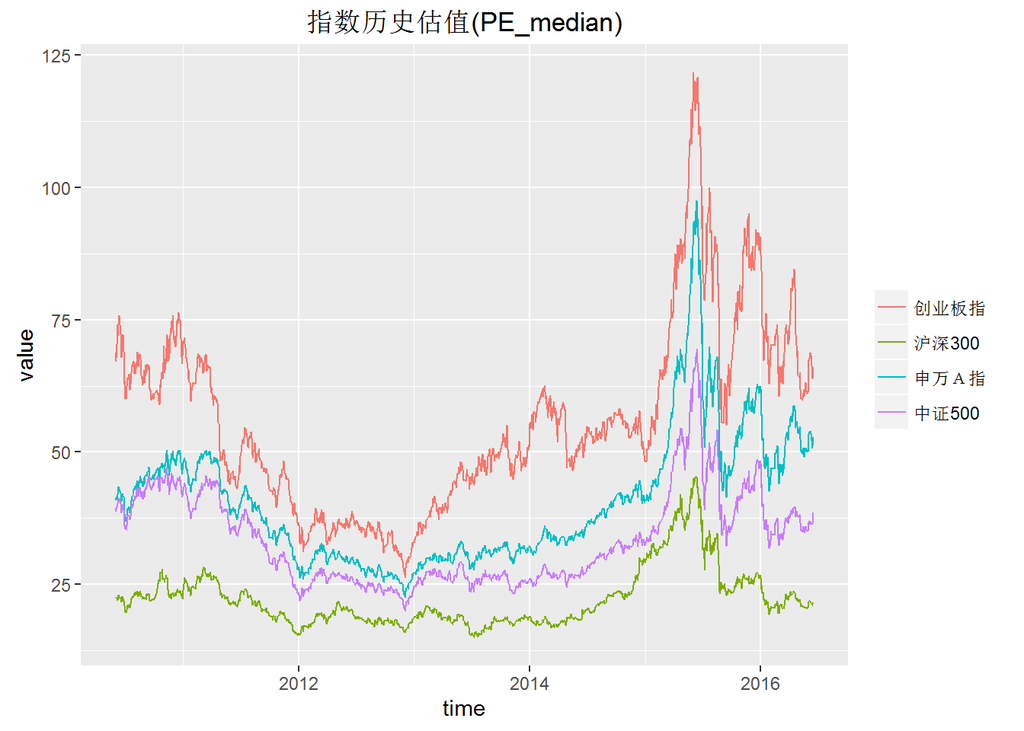

### (二)指数动态市盈率百分位

核心指数上述数据的百分位走势如下图所示：

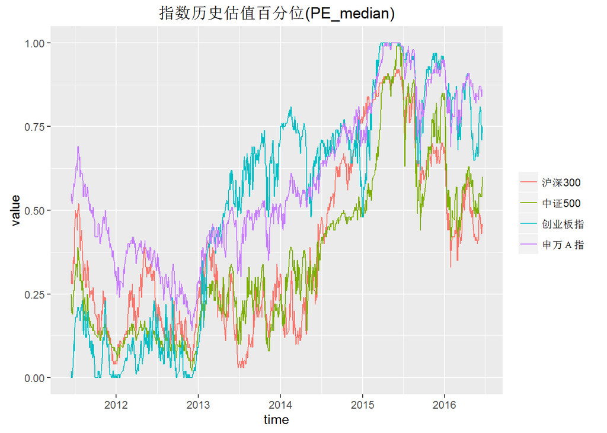

### (三)指数估值概览

纳入观察的18只指数最新的估值情况如下表：

| 日期 | 指数代码 | 指数简称 | 动态市盈率 | 上周动态市盈率 | 市盈率百分位 | 上周市盈率百分位 | 动态市净率 | 市净率百分位 |
| --- | --- | --- | --- | --- | --- | --- | --- | --- |
| 2016-06-16 | EI000979 | 大宗商品 | 44.25 | 41.12 | 0.92 | 0.89 | 2.41 | 0.40 |
| 2016-06-16 | EI000819 | 有色金属 | 60.85 | 46.85 | 0.91 | 0.77 | 4.38 | 0.90 |
| 2016-06-16 | EI801003 | 申万Ａ指 | 52.76 | 53.87 | 0.86 | 0.87 | 4.52 | 0.71 |
| 2016-06-16 | EI000805 | A股资源 | 43.96 | 28.72 | 0.83 | 0.65 | 2.36 | 0.48 |
| 2016-06-16 | EI399005 | 中小板指P | 43.93 | 45.00 | 0.78 | 0.81 | 5.12 | 0.59 |
| 2016-06-16 | EI399959 | 军工指数 | 87.73 | 89.06 | 0.76 | 0.77 | 5.75 | 0.74 |
| 2016-06-16 | EI399006 | 创业板指 | 65.08 | 68.79 | 0.73 | 0.81 | 7.14 | 0.74 |
| 2016-06-16 | EI000998 | 中证TMT | 55.70 | 59.54 | 0.72 | 0.78 | 5.76 | 0.74 |
| 2016-06-16 | EI801120 | 申万食品饮料 | 42.92 | 44.20 | 0.65 | 0.69 | 4.32 | 0.52 |
| 2016-06-16 | EI000905 | 中证500 | 38.50 | 36.74 | 0.60 | 0.55 | 3.43 | 0.53 |
| 2016-06-16 | EI000932 | 中证消费 | 32.75 | 31.71 | 0.50 | 0.45 | 4.20 | 0.41 |
| 2016-06-16 | EI399330 | 深证100 | 25.98 | 26.76 | 0.48 | 0.52 | 3.60 | 0.51 |
| 2016-06-16 | EI000933 | 中证医药 | 36.28 | 38.17 | 0.46 | 0.62 | 4.19 | 0.14 |
| 2016-06-16 | EI000300 | 沪深300 | 21.29 | 21.72 | 0.45 | 0.48 | 2.41 | 0.41 |
| 2016-06-16 | EI000808 | 医药生物 | 38.57 | 39.65 | 0.44 | 0.54 | 4.89 | 0.37 |
| 2016-06-16 | EI000827 | 中证环保 | 35.61 | 36.05 | 0.35 | 0.38 | 3.76 | 0.57 |
| 2016-06-16 | EI000934 | 中证金融 | 14.70 | 15.18 | 0.19 | 0.27 | 2.17 | 0.44 |
| 2016-06-16 | EI000016 | 上证50 | 11.56 | 12.11 | 0.05 | 0.09 | 1.41 | 0.01 |

## 二、基差

### (一)基差走势

三大股指期货隔季合约基差走势如下图：

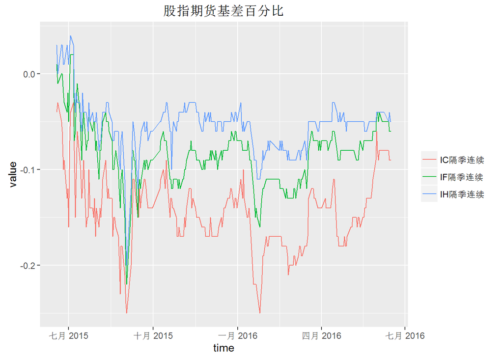

### (二)基差概况

三大股指期货连续合约基差概况如下表：

| 日期 | 合约简称 | 合约收盘价 | 基差 | 基差百分比 | 上周基差 | 上周基差百分比 |
| --- | --- | --- | --- | --- | --- | --- |
| 2016-06-16 | IH当月连续 | 2092.6 | -2.21 | 0.00 | -6.47 | 0.00 |
| 2016-06-16 | IH下月连续 | 2053.6 | -41.21 | -0.02 | -32.87 | -0.02 |
| 2016-06-16 | IH下季连续 | 2021.4 | -73.41 | -0.04 | -57.27 | -0.03 |
| 2016-06-16 | IH隔季连续 | 1996.0 | -98.81 | -0.05 | -85.67 | -0.04 |
| 2016-06-16 | IF当月连续 | 3088.0 | -6.67 | 0.00 | -17.05 | -0.01 |
| 2016-06-16 | IF下月连续 | 3028.8 | -65.87 | -0.02 | -55.05 | -0.02 |
| 2016-06-16 | IF下季连续 | 2972.0 | -122.67 | -0.04 | -102.85 | -0.03 |
| 2016-06-16 | IF隔季连续 | 2915.6 | -179.07 | -0.06 | -151.25 | -0.05 |
| 2016-06-16 | IC当月连续 | 5912.8 | -17.75 | 0.00 | -28.76 | 0.00 |
| 2016-06-16 | IC下月连续 | 5788.8 | -141.75 | -0.02 | -131.16 | -0.02 |
| 2016-06-16 | IC下季连续 | 5599.6 | -330.95 | -0.06 | -282.36 | -0.05 |
| 2016-06-16 | IC隔季连续 | 5400.2 | -530.35 | -0.09 | -470.36 | -0.08 |

## 三、套利

### (一)复牌股票套利

近两天复牌股票套利情况如下表：

[1] “无复牌股票套利”

## 四、择时

**任何指标都不能单一而绝对的发出买入卖出信号**，一个相对合理的择时模型应该是**基本面**和**技术面**的结合。以下关于技术分析的探索，还须和上面基于指数估值的探索相结合，至于如何结合，还需要进一步的研究。

### (一)大盘均线强弱指数

大盘均线强弱指数在一定程度上可以视为一个反转指标，当大盘均线得分接近8分时，预示市场接近顶部，当大盘均线得分接近0分时，预示市场接近底部。  
其原理是根据申万28个一级行业走势与其8均线(8,13,21,34,55,89,144,233)组合构造而来，譬如申万电子EI801080收盘价在8根均线之上，记为8分，在7根均线之上记为7分，以此类推，最后求28个一级行业的平均得分。  
大盘均线强弱指数近一年来走势如下图：

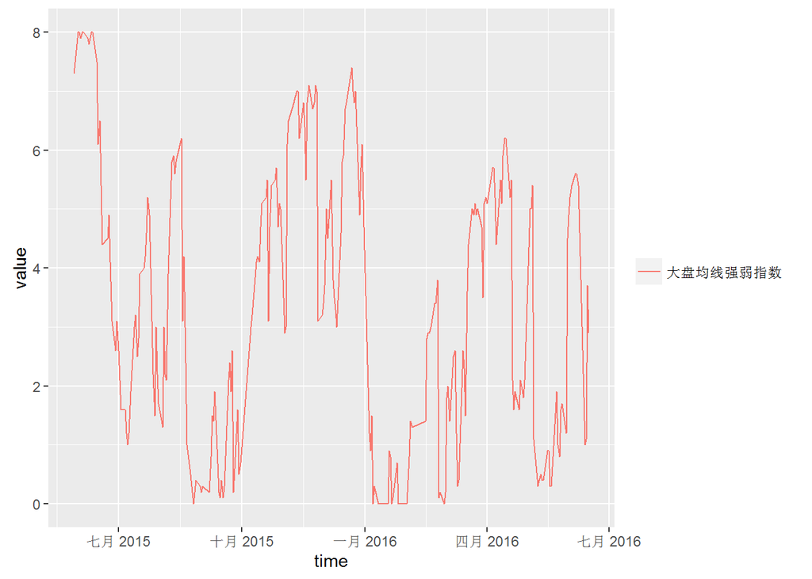

申万一级行业的最新得分及上周得分见下表：

| 日期 | 指数代码 | 指数名称 | 最新值 | 上周值 |
| --- | --- | --- | --- | --- |
| 2016-06-16 | EI801050 | 申万有色金属 | 8 | 8 |
| 2016-06-16 | EI801080 | 申万电子 | 8 | 8 |
| 2016-06-16 | EI801120 | 申万食品饮料 | 8 | 8 |
| 2016-06-16 | EI801880 | 申万汽车 | 8 | 7 |
| 2016-06-16 | EI801110 | 申万家用电器 | 6 | 8 |
| 2016-06-16 | EI801730 | 申万电气设备 | 6 | 6 |
| 2016-06-16 | EI801890 | 申万机械设备 | 6 | 6 |
| 2016-06-16 | EI801010 | 申万农林牧渔 | 5 | 6 |
| 2016-06-16 | EI801030 | 申万化工 | 5 | 6 |
| 2016-06-16 | EI801140 | 申万轻工制造 | 5 | 6 |
| 2016-06-16 | EI801740 | 申万国防军工 | 4 | 4 |
| 2016-06-16 | EI801770 | 申万通信 | 4 | 6 |
| 2016-06-16 | EI801230 | 申万综合 | 3 | 5 |
| 2016-06-16 | EI801750 | 申万计算机 | 2 | 6 |
| 2016-06-16 | EI801130 | 申万纺织服装 | 1 | 6 |
| 2016-06-16 | EI801160 | 申万公用事业 | 1 | 4 |
| 2016-06-16 | EI801710 | 申万建筑材料 | 1 | 5 |
| 2016-06-16 | EI801780 | 申万银行 | 1 | 6 |
| 2016-06-16 | EI801020 | 申万采掘 | 0 | 3 |
| 2016-06-16 | EI801040 | 申万钢铁 | 0 | 3 |
| 2016-06-16 | EI801150 | 申万医药生物 | 0 | 6 |
| 2016-06-16 | EI801170 | 申万交通运输 | 0 | 5 |
| 2016-06-16 | EI801180 | 申万房地产 | 0 | 4 |
| 2016-06-16 | EI801200 | 申万商业贸易 | 0 | 5 |
| 2016-06-16 | EI801210 | 申万休闲服务 | 0 | 4 |
| 2016-06-16 | EI801720 | 申万建筑装饰 | 0 | 4 |
| 2016-06-16 | EI801760 | 申万传媒 | 0 | 5 |
| 2016-06-16 | EI801790 | 申万非银金融 | 0 | 6 |

### (二)LLT及均线择时

LLT是参考广发的一个择时模型，跟踪了一段时间，表现还不错，所以自己重现了一下。创业板的择时直接用30天均线。择时模型的信号都依赖于收盘价，所以当日收盘后发出买入信号，次日开盘才能买入，单次交易成本千一。  
择时模型和指数本身的净值走势如下图：

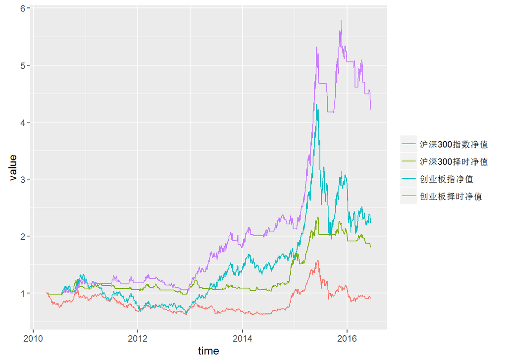

择时模型和指数的收益率统计如下表：

|  | 沪深300指 | 沪深300LLT | 创业板指 | 创业板MA |
| --- | --- | --- | --- | --- |
| 年化收益率 | -1.5 | 10.4 | 15.5 | 28.6 |
| 年化波动率 | 26.0 | 16.5 | 35.0 | 24.1 |
| 年化Sharpe值 | -5.8 | 63.1 | 44.4 | 118.8 |
| 最大回撤 | 46.7 | 22.6 | 54.9 | 27.3 |

择时模型最近10个交易日的信号如下表：

| 日期 | 沪深300收盘价 | 沪深300择时信号 | 创业板收盘价 | 创业板择时信号 |
| --- | --- | --- | --- | --- |
| 2016-06-01 | 3160.547 | hold | 2168.820 | hold |
| 2016-06-02 | 3167.100 | hold | 2188.558 | hold |
| 2016-06-03 | 3189.325 | hold | 2204.974 | hold |
| 2016-06-06 | 3178.788 | hold | 2199.301 | hold |
| 2016-06-07 | 3177.054 | hold | 2196.727 | hold |
| 2016-06-08 | 3163.986 | hold | 2186.544 | hold |
| 2016-06-13 | 3066.341 | sell | 2054.707 | sell |
| 2016-06-14 | 3075.983 |  | 2058.314 |  |
| 2016-06-15 | 3116.368 |  | 2128.799 | buy |
| 2016-06-16 | 3094.675 |  | 2101.416 | sell |